# TreeClassification-HighRes-IndividualUser

Aitor Apaolaza

12/01/2016

*Copyright (c) 2015 The University of Manchester, UK.*

*Licenced under LGPL version 2.1. See LICENCE for details.*

*The IDInteraction Attention Classification was developed in the IDInteraction project, funded by the Engineering and Physical Sciences Research Council, UK through grant agreement number EP/M017133/1.*

*Author: Aitor Apaolaza*

## Initialisation and loading data

```
## [1] "All listed packages are already installed"
```

# Setup for the classification algorithm.

**Folder**: /home/aitor/Dropbox/UoM/IDInteractionCode/Rnotebooks

**Experiment**: dual_screen_free_experiment

**Source Videos**: high_quality

**Tracking system**: front_eyes_only

**Using the following list of participants**: P06.

**Using the following timelimit threshold to separate training and testing data**: 1.

Data for these participants will be read from the CSV files contained in the following folders:

/home/aitor/Dropbox/UoM/IDInteractionCode/Rnotebooks/resources/dual_screen_free_experiment/high_quality/attention/

/home/aitor/Dropbox/UoM/IDInteractionCode/Rnotebooks/resources/dual_screen_free_experiment/high_quality/front_eyes_only/

Loading data for participant P06

```
## [1] "Processing participant: P06"
## [1] "START of combineCSVsToDF()"
## [1] "END of combineCSVsToDF()"
## [1] "START of createFeatureDF()"
## [1] "END of createFeatureDF()"
```

## Training the tree classifier

Using the **rpart** library for the following formula:

**attentionName ~ boxHeight + boxRotation + boxArea + boxWidth + widthHeightRatio + boxYcoordRel**

Resulting model:

```
## n= 2798
##
## node), split, n, loss, yval, (yprob)
##       * denotes terminal node
##
##  1) root 2798 1244 tv (0.444603288 0.555396712)
##    2) boxYcoordRel>=0.3938595 1489  275 ipad (0.815312290 0.184687710)
##      4) boxRotation>=8.590605 1324  169 ipad (0.872356495 0.127643505)
##        8) boxRotation< 18.4406 1167   97 ipad (0.916880891 0.083119109)
##         16) boxHeight>=24.8906 554    2 ipad (0.996389892 0.003610108) *
##         17) boxHeight< 24.8906 613   95 ipad (0.845024470 0.154975530)
##           34) boxYcoordRel>=0.4008062 509   16 ipad (0.968565815 0.031434185) *
##           35) boxYcoordRel< 0.4008062 104   25 tv (0.240384615 0.759615385) *
##        9) boxRotation>=18.4406 157   72 ipad (0.541401274 0.458598726)
##         18) boxHeight< 22.9512 85   12 ipad (0.858823529 0.141176471) *
##         19) boxHeight>=22.9512 72   12 tv (0.166666667 0.833333333) *
##      5) boxRotation< 8.590605 165   59 tv (0.357575758 0.642424242)
##       10) boxHeight< 20.09095 59    2 ipad (0.966101695 0.033898305) *
##       11) boxHeight>=20.09095 106    2 tv (0.018867925 0.981132075) *
##    3) boxYcoordRel< 0.3938595 1309   30 tv (0.022918258 0.977081742) *
```

From the R manual for the Complexity Parameter Table for an Rpart Fit: *The cptable in the fit contains the mean and standard deviation of the errors in the cross-validated prediction against each of the geometric means.*

Matrix of information on the optimal prunings based on a complexity parameter.

```
##
## Classification tree:
## rpart(formula = formula, data = trainsetclass, method = "class")
##
## Variables actually used in tree construction:
## [1] boxHeight    boxRotation  boxYcoordRel
##
## Root node error: 1244/2798 = 0.4446
##
## n= 2798
##
##         CP nsplit rel error  xerror      xstd
## 1 0.754823      0   1.00000 1.00000 0.0211296
## 2 0.040997      1   0.24518 0.24920 0.0133463
## 3 0.020498      3   0.16318 0.17042 0.0112522
## 4 0.010000      7   0.08119 0.10450 0.0089499
```

Visualisation of the Complexity Parameter Table. *A good choice of cp for pruning is often the leftmost value for which the mean lies below the horizontal line.*

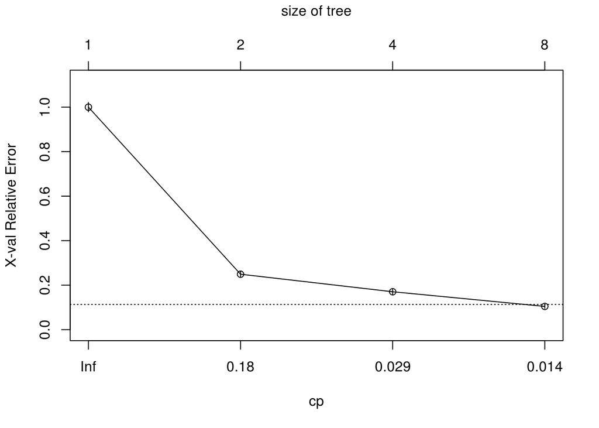

## Tree

### Summary of the tree

```
##
## Model formula:
## attentionName ~ boxHeight + boxRotation + boxArea + boxWidth +
##     widthHeightRatio + boxYcoordRel
##
## Fitted party:
## [1] root
## |   [2] boxYcoordRel >= 0.39386
## |   |   [3] boxRotation >= 8.59061
## |   |   |   [4] boxRotation < 18.4406
## |   |   |   |   [5] boxHeight >= 24.8906: ipad (n = 554, err = 0.4%)
## |   |   |   |   [6] boxHeight < 24.8906
## |   |   |   |   |   [7] boxYcoordRel >= 0.40081: ipad (n = 509, err = 3.1%)
## |   |   |   |   |   [8] boxYcoordRel < 0.40081: tv (n = 104, err = 24.0%)
## |   |   |   [9] boxRotation >= 18.4406
## |   |   |   |   [10] boxHeight < 22.9512: ipad (n = 85, err = 14.1%)
## |   |   |   |   [11] boxHeight >= 22.9512: tv (n = 72, err = 16.7%)
## |   |   [12] boxRotation < 8.59061
## |   |   |   [13] boxHeight < 20.09095: ipad (n = 59, err = 3.4%)
## |   |   |   [14] boxHeight >= 20.09095: tv (n = 106, err = 1.9%)
## |   [15] boxYcoordRel < 0.39386: tv (n = 1309, err = 2.3%)
##
## Number of inner nodes:    7
## Number of terminal nodes: 8
```

### Visualisation of the tree

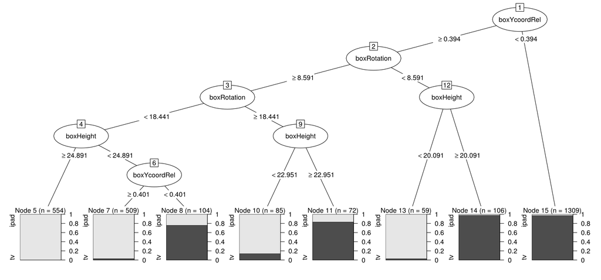

Tree classifier plot

## Error metrics analysis

Confusion matrix from the application of the tree predictor to the testing set of data.

```
##       predclass
##         ipad    tv
##   ipad  5968  7192
##   tv    8099 21910
```

### Error metrics based on prediction of attention to the iPad.

True negatives: 21910

False negatives: 8099

True positives: 5968

False positives: 7192

**Error-rate**: the proportion of the incorrectly classified examples -> (fp+fn)/(tp+tn+fp+tn)

**35.4212514**

**Accuracy**: the proportion of the correctly classified examples -> (tp+tn)/(tp+tn+fp+tn)

**64.5787486**

As the number of instances of the response variable is not balanced (there are many more instances with false than true) the accuracy is not a good indicator. Other cost sensitive measures are reported here. -> cost sensitive measures

**Precision**: positive predicted value (PPV) -> tp/(tp+fp), a measure of exactness

**45.3495441**

**Recall/Sensitivity**: true positive recognition rate -> tp/(tp+fn), a measure of completeness

**42.4255349**

**Specificity**: true negative recognition rate -> tn/(tn+fp)

**75.2869219**

**F measure**: the balance between precision and recall -> 2*tp/(2*tp+fp+fn)

**43.8388364**

# ERROR MEASURES INLINE COPY

P06 **35.4212514** **64.5787486** **45.3495441** **42.4255349** **75.2869219** **43.8388364**

### Error metrics based on prediction of attention to the TV.

True negatives: 5968

False negatives: 7192

True positives: 21910

False positives: 8099

**Error-rate**: the proportion of the incorrectly classified examples -> (fp+fn)/(tp+tn+fp+tn)

**35.4212514**

**Accuracy**: the proportion of the correctly classified examples -> (tp+tn)/(tp+tn+fp+tn)

**64.5787486**

**Precision**: positive predicted value (PPV) -> tp/(tp+fp), a measure of exactness

**73.0114299**

**Recall/Sensitivity**: true positive recognition rate -> tp/(tp+fn), a measure of completeness

**75.2869219**

**Specificity**: true negative recognition rate -> tn/(tn+fp)

**42.4255349**

**F measure**: the balance between precision and recall -> 2*tp/(2*tp+fp+fn)

**74.1317183**